# Linear Regression

## Aims

For continous data:

Understand linear regression with one predictor and two predictors

Understand how we assess the fit of a regression model

- Total sum of squares
- Model sum of squares
- Residual sum of squares
- F
- R<sup>2</sup>

Know how to do regression using R

Interpret a regression model

## What is Regression?

A way of predicting the value of one variable from another

- It is a hypothetical model of the relationship between two variables
- The model used is a linear one
- Therefore, we describe the relationship using the equation of a straight line

This week focuses on linear regression with **continous predictors (IVs)**. This means our predictors (IVs) will be on a numeric scale of some sort. (Next week we will work on categorical data where data is not numeric, but in categories instead).

## Describing a Straight Line

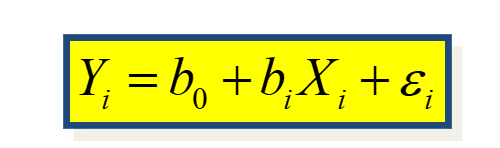

**b<sub>0</sub>:** Represents the **Intercept** (value of Y when X = 0)

- Point at which the regression line crosses the Y-axis (ordinate)

**b<sub>i</sub>:** Regression coefficient for the predictor

- **Slope** of the regression line
  - Direction/strength of relationship

## Intercepts and Slopes

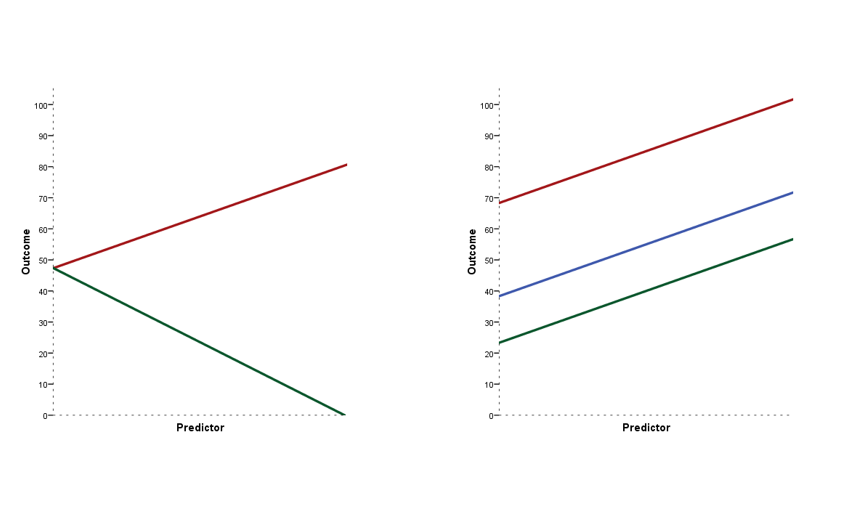

The image on the **left** shows a case where the two lines share the same intercept (value when = 0) but have different slopes (direction & strength of relationship)

## The Method of Least Squares

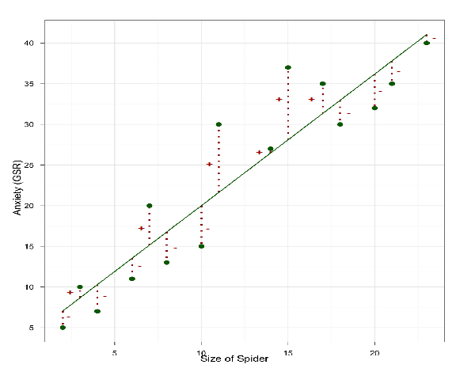

This graph shows a scatterplot of some data with a line representing the general trend

The vertical lines (dotted) represent the differences (or **residuals**) between the line and the actual data

## How Good is the Model?

The regression line is only a model based on the data

This model might not reflect reality

- We need some way of testing how well the model fits the observed data.
- How?

## Sums of Squares

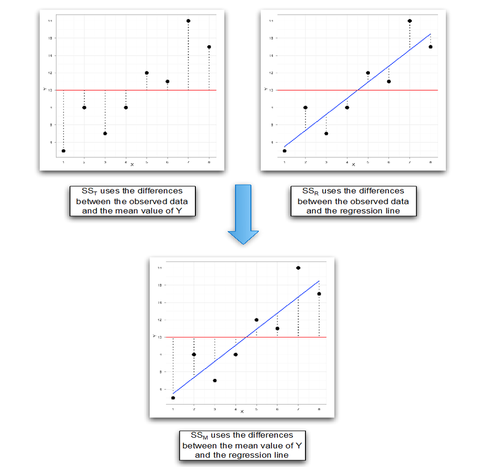

Diagram showing from where the regression sums of squares derive

### Sum of Squares Summary

SS<sub>T</sub>: Total variability (variability between scores and the mean)

SS<sub>R</sub>: Residual/error variability (variability between the regression model and the actual data)

SS<sub>M</sub>: Model variability (difference in variability between the model and the mean)

## Testing the Model: ANOVA

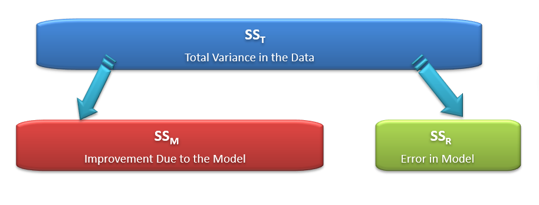

If the model results in better prediction than using the mean, then we expect SS<sub>M</sub> to be much greater than SS<sub>R</sub>

### Mean Squared Error

Sums of squares are total values

They can be expressed as averages

These are called mean squares, MS

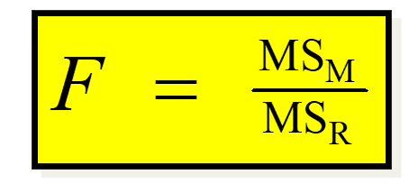